# JDM Week2 Assignment

Jiaqi Yu

1/17/2021

### Recruiter A

#### Run main effect simple models for each of the independent variables

```
##
## Call:
## lm(formula = RATING ~ INTRVW, data = mydata_A)
##
## Residuals:
##     Min      1Q  Median      3Q     Max
## -54.526 -11.359  -2.215  14.785  34.363
##
## Coefficients:
##             Estimate Std. Error t value Pr(>|t|)
## (Intercept)  26.9036     4.0374   6.664 1.39e-09 ***
## INTRVW        4.5777     0.8273   5.533 2.44e-07 ***
## ---
## Signif. codes:  0 '***' 0.001 '**' 0.01 '*' 0.05 '.' 0.1 ' ' 1
##
## Residual standard error: 17.91 on 102 degrees of freedom
## Multiple R-squared:  0.2309, Adjusted R-squared:  0.2233
## F-statistic: 30.62 on 1 and 102 DF,  p-value: 2.442e-07
```

```
##
## Call:
## lm(formula = RATING ~ RECS, data = mydata_A)
##
## Residuals:
##     Min      1Q  Median      3Q     Max
## -43.448 -15.112  -0.685  13.986  47.552
##
## Coefficients:
##             Estimate Std. Error t value Pr(>|t|)
## (Intercept) 40.63165    9.22053   4.407  2.6e-05 ***
## RECS         0.08948    0.12610   0.710     0.48
## ---
## Signif. codes:  0 '***' 0.001 '**' 0.01 '*' 0.05 '.' 0.1 ' ' 1
##
## Residual standard error: 20.38 on 102 degrees of freedom
## Multiple R-squared:  0.004913,   Adjusted R-squared:  -0.004843
## F-statistic: 0.5036 on 1 and 102 DF,  p-value: 0.4796
```

```
##
## Call:
## lm(formula = RATING ~ SCHOOL, data = mydata_A)
##
## Residuals:
##     Min      1Q  Median      3Q     Max
## -35.235 -14.875  -0.787  12.518  44.468
##
## Coefficients:
##             Estimate Std. Error t value Pr(>|t|)
## (Intercept) 37.23046    3.78682   9.832   <2e-16 ***
## SCHOOL       0.25106    0.08371   2.999   0.0034 **
## ---
## Signif. codes:  0 '***' 0.001 '**' 0.01 '*' 0.05 '.' 0.1 ' ' 1
##
## Residual standard error: 19.58 on 102 degrees of freedom
## Multiple R-squared:  0.08103,    Adjusted R-squared:  0.07202
## F-statistic: 8.994 on 1 and 102 DF,  p-value: 0.003403
```

```
##
## Call:
## lm(formula = RATING ~ EXPRNC, data = mydata_A)
##
## Residuals:
##     Min      1Q  Median      3Q     Max
## -42.029 -15.873  -1.236  14.095  46.742
##
## Coefficients:
##             Estimate Std. Error t value Pr(>|t|)
## (Intercept)  45.0289     3.9608  11.369   <2e-16 ***
## EXPRNC        0.3185     0.5470   0.582    0.562
## ---
## Signif. codes:  0 '***' 0.001 '**' 0.01 '*' 0.05 '.' 0.1 ' ' 1
##
## Residual standard error: 20.39 on 102 degrees of freedom
## Multiple R-squared:  0.003312,   Adjusted R-squared:  -0.00646
## F-statistic: 0.3389 on 1 and 102 DF,  p-value: 0.5618
```

```
##
## Call:
## lm(formula = RATING ~ AGE, data = mydata_A)
##
## Residuals:
##     Min      1Q  Median      3Q     Max
## -41.027 -14.470   0.569  13.759  46.322
##
## Coefficients:
##             Estimate Std. Error t value Pr(>|t|)
## (Intercept)  60.9561    14.8005   4.119 7.76e-05 ***
## AGE          -0.3494     0.3677  -0.950    0.344
## ---
## Signif. codes:  0 '***' 0.001 '**' 0.01 '*' 0.05 '.' 0.1 ' ' 1
##
## Residual standard error: 20.34 on 102 degrees of freedom
## Multiple R-squared:  0.008776,   Adjusted R-squared:  -0.0009418
## F-statistic: 0.9031 on 1 and 102 DF,  p-value: 0.3442
```

```
##
## Call:
## lm(formula = RATING ~ SEX, data = mydata_A)
##
## Residuals:
##     Min      1Q  Median      3Q     Max
## -42.096 -15.192  -0.096  14.942  45.058
##
## Coefficients:
##             Estimate Std. Error t value Pr(>|t|)
## (Intercept)   47.019      1.994  23.583   <2e-16 ***
## SEX            1.923      1.994   0.965    0.337
## ---
## Signif. codes:  0 '***' 0.001 '**' 0.01 '*' 0.05 '.' 0.1 ' ' 1
##
## Residual standard error: 20.33 on 102 degrees of freedom
## Multiple R-squared:  0.009038,   Adjusted R-squared:  -0.000677
## F-statistic: 0.9303 on 1 and 102 DF,  p-value: 0.3371
```

```
##
## Call:
## lm(formula = RATING ~ ATTRACT, data = mydata_A)
##
## Residuals:
##     Min      1Q  Median      3Q     Max
## -44.579 -15.916  -0.904  14.526  46.003
##
## Coefficients:
##             Estimate Std. Error t value Pr(>|t|)
## (Intercept)  45.0669     4.4003  10.242   <2e-16 ***
## ATTRACT       0.4186     0.8404   0.498    0.619
## ---
## Signif. codes:  0 '***' 0.001 '**' 0.01 '*' 0.05 '.' 0.1 ' ' 1
##
## Residual standard error: 20.4 on 102 degrees of freedom
## Multiple R-squared:  0.002427,   Adjusted R-squared:  -0.007353
## F-statistic: 0.2481 on 1 and 102 DF,  p-value: 0.6195
```

```
##
## Call:
## lm(formula = RATING ~ INTRVW + SCHOOL, data = mydata_A)
##
## Residuals:
##     Min      1Q  Median      3Q     Max
## -45.865 -13.349  -0.616  12.114  34.491
##
## Coefficients:
##             Estimate Std. Error t value Pr(>|t|)
## (Intercept) 20.15665    4.64164   4.343 3.35e-05 ***
## INTRVW       4.31320    0.80862   5.334 5.90e-07 ***
## SCHOOL       0.20285    0.07486   2.710  0.00791 **
## ---
## Signif. codes:  0 '***' 0.001 '**' 0.01 '*' 0.05 '.' 0.1 ' ' 1
##
## Residual standard error: 17.38 on 101 degrees of freedom
## Multiple R-squared:  0.283,  Adjusted R-squared:  0.2688
## F-statistic: 19.93 on 2 and 101 DF,  p-value: 5.051e-08
```

#### Draw the residual plot for recruiter A

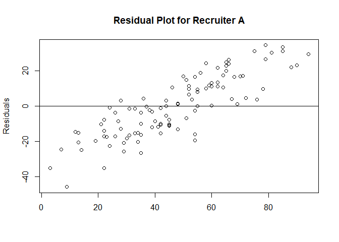

##### It seems that the residual is still positively correlated with the DV so the model did not capture the policy of recruiter A well.

#### Draw graphs for each of the variables in the current model for recruiter A

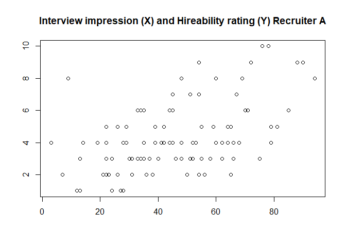

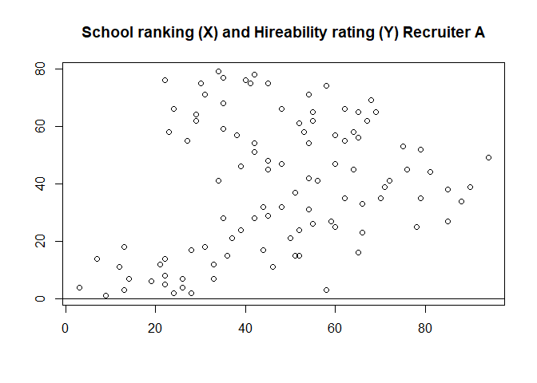

#### Add a quadratic term of school in model lm8 —now model 9

```
##
## Call:
## lm(formula = RATING ~ INTRVW + SCHOOL + SCHOOL_2, data = mydata_A)
##
## Residuals:
##     Min      1Q  Median      3Q     Max
## -28.922 -11.568   2.415   8.898  39.148
##
## Coefficients:
##              Estimate Std. Error t value Pr(>|t|)
## (Intercept)  4.746231   4.650410   1.021     0.31
## INTRVW       2.930455   0.722550   4.056 9.91e-05 ***
## SCHOOL       1.833280   0.267313   6.858 5.87e-10 ***
## SCHOOL_2    -0.020566   0.003275  -6.280 8.81e-09 ***
## ---
## Signif. codes:  0 '***' 0.001 '**' 0.01 '*' 0.05 '.' 0.1 ' ' 1
##
## Residual standard error: 14.79 on 100 degrees of freedom
## Multiple R-squared:  0.4858, Adjusted R-squared:  0.4704
## F-statistic: 31.49 on 3 and 100 DF,  p-value: 2.036e-14
```

#### Draw the residual plot again to check for correlations

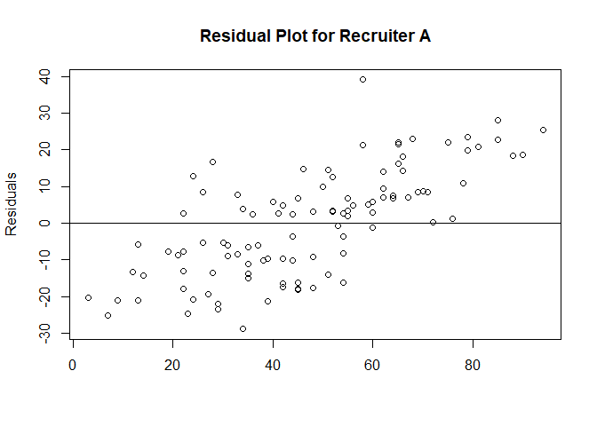

### Recruiter B

#### Run main effect simple models for each of the independent variables

```
##
## Call:
## lm(formula = RATING ~ INTRVW, data = mydata_B)
##
## Residuals:
##     Min      1Q  Median      3Q     Max
## -58.784 -12.932  -3.064  12.598  55.509
##
## Coefficients:
##             Estimate Std. Error t value Pr(>|t|)
## (Intercept)  26.3443     4.3418   6.068 2.23e-08 ***
## INTRVW        4.3822     0.8815   4.971 2.69e-06 ***
## ---
## Signif. codes:  0 '***' 0.001 '**' 0.01 '*' 0.05 '.' 0.1 ' ' 1
##
## Residual standard error: 19.3 on 102 degrees of freedom
## Multiple R-squared:  0.195,  Adjusted R-squared:  0.1871
## F-statistic: 24.71 on 1 and 102 DF,  p-value: 2.694e-06
```

```
##
## Call:
## lm(formula = RATING ~ RECS, data = mydata_B)
##
## Residuals:
##     Min      1Q  Median      3Q     Max
## -39.305 -15.262  -1.598  12.712  51.110
##
## Coefficients:
##             Estimate Std. Error t value Pr(>|t|)
## (Intercept)  24.7595     9.5004   2.606   0.0105 *
## RECS          0.2943     0.1299   2.265   0.0256 *
## ---
## Signif. codes:  0 '***' 0.001 '**' 0.01 '*' 0.05 '.' 0.1 ' ' 1
##
## Residual standard error: 20.99 on 102 degrees of freedom
## Multiple R-squared:  0.0479, Adjusted R-squared:  0.03856
## F-statistic: 5.131 on 1 and 102 DF,  p-value: 0.02561
```

```
##
## Call:
## lm(formula = RATING ~ SCHOOL, data = mydata_B)
##
## Residuals:
##     Min      1Q  Median      3Q     Max
## -41.858 -16.910  -2.451  14.094  49.260
##
## Coefficients:
##             Estimate Std. Error t value Pr(>|t|)
## (Intercept) 49.20168    4.18195  11.765   <2e-16 ***
## SCHOOL      -0.08596    0.09056  -0.949    0.345
## ---
## Signif. codes:  0 '***' 0.001 '**' 0.01 '*' 0.05 '.' 0.1 ' ' 1
##
## Residual standard error: 21.42 on 102 degrees of freedom
## Multiple R-squared:  0.008756,   Adjusted R-squared:  -0.0009624
## F-statistic: 0.901 on 1 and 102 DF,  p-value: 0.3448
```

```
##
## Call:
## lm(formula = RATING ~ EXPRNC, data = mydata_B)
##
## Residuals:
##     Min      1Q  Median      3Q     Max
## -36.662 -16.840  -3.877  15.264  52.627
##
## Coefficients:
##             Estimate Std. Error t value Pr(>|t|)
## (Intercept)  43.0839     4.1677  10.338   <2e-16 ***
## EXPRNC        0.4297     0.5756   0.746    0.457
## ---
## Signif. codes:  0 '***' 0.001 '**' 0.01 '*' 0.05 '.' 0.1 ' ' 1
##
## Residual standard error: 21.46 on 102 degrees of freedom
## Multiple R-squared:  0.005432,   Adjusted R-squared:  -0.004318
## F-statistic: 0.5571 on 1 and 102 DF,  p-value: 0.4571
```

```
##
## Call:
## lm(formula = RATING ~ AGE, data = mydata_B)
##
## Residuals:
##     Min      1Q  Median      3Q     Max
## -38.519 -14.879  -2.064  14.467  50.184
##
## Coefficients:
##             Estimate Std. Error t value Pr(>|t|)
## (Intercept)  63.7355    15.5559   4.097  8.4e-05 ***
## AGE          -0.4505     0.3865  -1.166    0.247
## ---
## Signif. codes:  0 '***' 0.001 '**' 0.01 '*' 0.05 '.' 0.1 ' ' 1
##
## Residual standard error: 21.37 on 102 degrees of freedom
## Multiple R-squared:  0.01314,    Adjusted R-squared:  0.003469
## F-statistic: 1.359 on 1 and 102 DF,  p-value: 0.2465
```

```
##
## Call:
## lm(formula = RATING ~ SEX, data = mydata_B)
##
## Residuals:
##     Min      1Q  Median      3Q     Max
## -38.750 -16.000  -2.769  16.212  51.250
##
## Coefficients:
##             Estimate Std. Error t value Pr(>|t|)
## (Intercept) 45.76923    2.10974  21.694   <2e-16 ***
## SEX          0.01923    2.10974   0.009    0.993
## ---
## Signif. codes:  0 '***' 0.001 '**' 0.01 '*' 0.05 '.' 0.1 ' ' 1
##
## Residual standard error: 21.52 on 102 degrees of freedom
## Multiple R-squared:  8.146e-07,  Adjusted R-squared:  -0.009803
## F-statistic: 8.309e-05 on 1 and 102 DF,  p-value: 0.9927
```

```
##
## Call:
## lm(formula = RATING ~ ATTRACT, data = mydata_B)
##
## Residuals:
##     Min      1Q  Median      3Q     Max
## -44.268 -16.210  -1.622  14.196  43.837
##
## Coefficients:
##             Estimate Std. Error t value Pr(>|t|)
## (Intercept)  37.7048     4.5533   8.281 5.01e-13 ***
## ATTRACT       1.7293     0.8697   1.988   0.0494 *
## ---
## Signif. codes:  0 '***' 0.001 '**' 0.01 '*' 0.05 '.' 0.1 ' ' 1
##
## Residual standard error: 21.11 on 102 degrees of freedom
## Multiple R-squared:  0.03732,    Adjusted R-squared:  0.02788
## F-statistic: 3.954 on 1 and 102 DF,  p-value: 0.04944
```

```
##
## Call:
## lm(formula = RATING ~ INTRVW + RECS + ATTRACT, data = mydata_B)
##
## Residuals:
##     Min      1Q  Median      3Q     Max
## -57.678 -12.991  -2.239  11.088  43.661
##
## Coefficients:
##             Estimate Std. Error t value Pr(>|t|)
## (Intercept)  -2.3233    10.0046  -0.232   0.8168
## INTRVW        4.2266     0.8605   4.912 3.53e-06 ***
## RECS          0.3281     0.1154   2.844   0.0054 **
## ATTRACT       1.2722     0.7784   1.634   0.1053
## ---
## Signif. codes:  0 '***' 0.001 '**' 0.01 '*' 0.05 '.' 0.1 ' ' 1
##
## Residual standard error: 18.58 on 100 degrees of freedom
## Multiple R-squared:  0.269,  Adjusted R-squared:  0.247
## F-statistic: 12.26 on 3 and 100 DF,  p-value: 6.732e-07
```

```
##
## Call:
## lm(formula = RATING ~ INTRVW + RECS, data = mydata_B)
##
## Residuals:
##    Min     1Q Median     3Q    Max
## -57.12 -12.99  -2.26  13.55  49.77
##
## Coefficients:
##             Estimate Std. Error t value Pr(>|t|)
## (Intercept)   3.6100     9.3995   0.384    0.702
## INTRVW        4.4570     0.8559   5.208 1.01e-06 ***
## RECS          0.3138     0.1160   2.706    0.008 **
## ---
## Signif. codes:  0 '***' 0.001 '**' 0.01 '*' 0.05 '.' 0.1 ' ' 1
##
## Residual standard error: 18.73 on 101 degrees of freedom
## Multiple R-squared:  0.2494, Adjusted R-squared:  0.2346
## F-statistic: 16.78 on 2 and 101 DF,  p-value: 5.095e-07
```

```
##
## Call:
## lm(formula = RATING ~ ATTRACT * SEX, data = mydata_B)
##
## Residuals:
##     Min      1Q  Median      3Q     Max
## -47.374 -10.488  -0.712  13.726  39.729
##
## Coefficients:
##             Estimate Std. Error t value Pr(>|t|)
## (Intercept) 47.28208    4.08780  11.567  < 2e-16 ***
## ATTRACT      0.01204    0.77638   0.016    0.988
## SEX         24.56283    4.08780   6.009 3.05e-08 ***
## ATTRACT:SEX -5.26373    0.77638  -6.780 8.52e-10 ***
## ---
## Signif. codes:  0 '***' 0.001 '**' 0.01 '*' 0.05 '.' 0.1 ' ' 1
##
## Residual standard error: 17.64 on 100 degrees of freedom
## Multiple R-squared:  0.3409, Adjusted R-squared:  0.3211
## F-statistic: 17.24 on 3 and 100 DF,  p-value: 4.252e-09
```

```
##
## Call:
## lm(formula = RATING ~ INTRVW + RECS + ATTRACT * SEX, data = mydata_B)
##
## Residuals:
##     Min      1Q  Median      3Q     Max
## -59.219  -9.621  -0.426  11.145  41.549
##
## Coefficients:
##             Estimate Std. Error t value Pr(>|t|)
## (Intercept) 20.24797    9.62164   2.104   0.0379 *
## INTRVW       3.27036    0.77283   4.232 5.23e-05 ***
## RECS         0.17833    0.10446   1.707   0.0909 .
## ATTRACT     -0.08946    0.72793  -0.123   0.9024
## SEX         20.44801    3.93950   5.191 1.14e-06 ***
## ATTRACT:SEX -4.32179    0.75465  -5.727 1.12e-07 ***
## ---
## Signif. codes:  0 '***' 0.001 '**' 0.01 '*' 0.05 '.' 0.1 ' ' 1
##
## Residual standard error: 16.24 on 98 degrees of freedom
## Multiple R-squared:  0.4523, Adjusted R-squared:  0.4244
## F-statistic: 16.19 on 5 and 98 DF,  p-value: 1.305e-11
```

#### Draw the residual plot for recruiter B

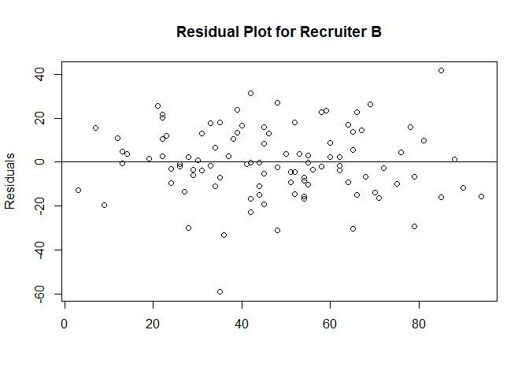

##### I think the corresponding Cognitive Algebra Model in this case is averaging, since 1) there are observed (or perhaps even unobserved) interactions between different variables in the regression models that would create a “crossing” pattern if we illustrate the variables and the DV on a figure like figure 2.5 in the book (for recruiter B’s model–the interaction between sex and attractiveness) and 2) the models seem to align with a weighted averaging rule and has a weight parameter in its operation. The averaging rule tells us that each bit of information has two important qualities, weight and value. The value of a bit of information is its evaluation (favorable or unfavorable) and the weight is the information’s perceived importance.

##### In a general sense, the model can be used to predict how likely an applicant will get hired based on hireability scores. If I have done a more realistic analysis with more cues and better-fitting models, the predicted scores should have a strong correlation with the actual hireabilty scores. This model can help applicants themselves not only in predicting but also in improving their chances of being hired. For example, if the model has a good-fit and shows that a recruiter only cares about school rankings and interview impressions, then the applicant should try to get into a good MBA program and spend a lot of time in preparing for interviews.